# L’expérience républicaine

De la chute de la monarchie à Thermidor

Auteur·rice

Skarbimir Prokopek

Le récit de la Révolution française qui s’est formé déjà sous la III<sup>e</sup> République modérée, et qui a encore imprégné la célébration du Bicentenaire (1989) et les nombreuses productions sur la Révolution qui ont vu le jour à ce moment-là, tend à valoriser la révolution modérée et raisonnable de 1789, qui serait une application attendue des idées des Lumières, et la révolution excessive et violente de 1793.  
Ce récit ne tient pas: d’une part, il faut absolument envisager la révolution comme un tout. D’autre part, il faut l’envisager comme un processus qui ne saurait être dirigé ou arrêté à volonté, faute de quoi on confondrait la révolution avec un coup d’État.

## 1 Le feu est aux Tuileries: la chute de la monarchie

La monarchie constitutionnelle avait été l’horizon d’attente commun des révolutionnaires de la première heure, dont beaucoup apparaissent comme des modérés, voire conservateurs, dès l’été 1789. En principe, ce type de régime, déjà éprouvé en Angleterre depuis un siècle (le *Bill of rights* anglais fête ses cent ans en 1789), est fait pour la stabilité; elle restera le premier choix de la classe sociale la plus préoccupée par la stabilité, la bourgeoisie, durant la majeure partie du xix<sup>e</sup> siècle.  
Et pourtant, la monarchie constitutionnelle, instaurée en 1789, dont la constitution est achevée en 1791, est un régime mort-né.

### 1.1 La fuite de Varennes: la monarchie compromise

La difficulté de faire accepter au roi les décrets du 4 août et la Déclaration des droits de l’homme et du citoyen (DDHC) elle-même illustre une première faille du régime: le roi, déchu de son mandat divin, reste un élément clé et dispose d’un pouvoir de nuisance important. Or, ce roi, que les circonstances forcent parfois à montrer son acceptation de la révolution, n’accepte au fond rien du tout. Le veto est son principal instrument politique, dont il use pour faire modifier la constitution dans son sens: pour éviter qu’il ne refuse de ratifier la constitution, on lui accorde de renforcer son caractère **censitaire** et on accepte l’amnistie que le roi réclamait pour ses soutiens.  
Mais à ce moment, en septembre 1791, la monarchie constitutionnelle est déjà intenable. Elle est compromise plus tôt, dès le mois de juin 1791. Le 21, le peuple de Paris apprend la fuite du roi. D’une manière incroyablement maladroite, le couple royal quitte Paris pour rejoindre les **émigrés**, partisans radicaux de l’Ancien régime, ainsi que les armées des puissances monarchiques de l’Europe, en particulier l’Autriche, dont la reine Marie-Antoinette est originaire, et la Prusse. Ils doivent retrouver le marquis de Bouillé à Metz, qui doit les escorter jusqu’à la frontière. La tentative échoue: à Sainte-Menehould, le maître de postes Drouet reconnait le couple royal, qui est arrêté à Varennes, dans l’Argonne, et ramené de force à Paris.

[figure not shown]

*Les cochons ramenés à l’étable*, estampe coloriée sur papier d’après une gravure à l’eau-forte, 1791, BNF

Dans la capitale, ils sont accueillis par un silence de mort. Il est alors clair que la tentative de fuite équivaut à la haute trahison. La preuve est faite que le couple royal n’accepte rien de la Révolution qui s’est imposée par la force: Louis XVI et Marie-Antoinette n’attendent qu’une occasion de retrouver l’entièreté de leur pouvoir (absolu). Pire, ils sont prêts à s’allier avec les puissances voisines et hostiles (l’hostilité n’est pas nouvelle: l’inquiétude des monarchies européennes devant ce qui se passe en France ne fait que rejoindre l’hostilité déjà présente, héritée des guerres du xvii<sup>e</sup> et xviii<sup>e</sup> siècle) pour restaurer leur pouvoir monarchique par la guerre contre leur propre pays.  
Les représentations du roi, jusque-là toujours respecté, sont alors enlevées, et des pétitions se multiplient en faveur de la **déchéance de la monarchie**.

Dans un premier temps, l’Assemblée et toutes les forces conservatrices s’acharnent à limiter les conséquences de cet événement. Le 15 juillet, le roi est déclaré inviolable, et l’Assemblée invente la fiction (que personne ne croit) de l’enlèvement du roi. C’est que les conséquences font peur, ce que le député Barnave exprime très directement:

> Tout changement dans la Constitution est fatal, tout prolongement de la Révolution est désastreux… Je place ici la véritable question: allons-nous terminer la Révolution, allons-nous la recommencer? Si vous vous défiez de la Constitution, quel est le point où vous vous arrêterez? […] Un pas de plus dans la ligne de la liberté serait la destruction de la royauté, dans la ligne de l’égalité, la destruction de la propriété. […] Quand l’égalité de tous les hommes est assurée, trouverait-on encore une aristocratie à abattre, si ce n’est celle des propriétés?

Or, précisément, pour toute une fraction des révolutionnaires de la première heure désormais devenus des conservateurs, il ne faut surtout pas toucher à la propriété, et pour cela, il faut protéger la royauté à tout prix; la Révolution doit être, à leurs yeux, consignée au passé.

Une autre paire de clous dans le cercueil de la monarchie vient de l’étranger. Le 27 août 1791, la **déclaration de Pillnitz**, nommée d’après le château en Saxe où elle est signée, est proclamée par l’**empereur Léopold II** et le **roi de Prusse, Frédéric-Guillaume II**, sous la pression des plus éminents **émigrés** français: Calonne, marquis de Bouillé, duc de Choiseul, et surtout le **comte d’Artois**, futur roi Charles X.  
La déclaration est menaçante et elle provoque une réaction d’outrage à Paris. Il s’agit de défendre l’«honneur du nom français», et en apparence, tout le monde s’accorde là-dessus. En réalité, le roi qui publiquement exige que l’électeur de Trêves disperse les émigrés, négocie secrètement dans le sens contraire: la guerre est, pour les partisans de l’Ancien régime, un recours possible. Une partie des révolutionnaires sont du même avis: pour les **brissotins** (partisans de Brissot) et le réseau des **Rolandins** (dont Manon Roland), la guerre a un double intérêt: elle permettrait d’**exporter la révolution**, et elle forcerait le roi à révéler ses vraies positions. **Robespierre** s’oppose à cette position.

> La ville de Paris et tous ses habitants sans distinction seront tenus de se soumettre sur le champ et sans délai au roi, de mettre ce prince en pleine et entière liberté, et de lui assurer, ainsi qu’à toutes les personnes royales, l’inviolabilité et le respect auxquels le droit de la nature et des gens oblige les sujets envers les souverains ; leurs Majestés impériale et royale [*l’Empereur d’Autriche et le roi de Prusse*] rendant personnellement responsables de tous les événements, sur leur tête, pour être jugés militairement, sans espoir de pardon, tous les membres de l’Assemblée nationale, du département, du district, de la municipalité et de la garde nationale de Paris, les juges de paix et tous les autres qu’il appartiendra, déclarant en outre, leurs dites majestés, sur leur foi et parole d’Empereur et de roi, que si le château des Tuileries est forcé ou insulté, que s’il est fait la moindre violence, le moindre outrage à leurs Majestés, le roi, la reine et la famille royale, s’il n’est pas pourvu immédiatement à leur sûreté, à leur conservation et à leur liberté, elles en tireront une vengeance exemplaire et à jamais mémorable, en livrant la ville de Paris à une exécution militaire et à une subversion totale, et les révoltés coupables d’attentats aux supplices qu’ils auront mérités.

> *Le manifeste de Brunswick*, donné au quartier-général de Coblence le 25 juillet 1792, signé Charles-Guillaume-Ferdiand, duc de Brunswick-Lunebourg

### 1.2 La fusillade du Champ de Mars: une attente républicaine

La fuite du roi (*fuite de Varennes*) modifie immédiatement la situation: l’opposition entre ceux qui veulent arrêter la révolution là où elle est (considérant qu’une fois les privilèges de naissance et l’arbitraire royal supprimés, elle avait accompli son rôle) et ceux qui veulent qu’elle aille plus loin, se tend. Alors que l’Assemblée et la fraction rassemblée autour de La Fayette tentent fébrilement de contenir la situation, une demande populaire d’abolition de la monarchie s’affirme.  
Dès le 15 juillet une pétition est présentée pour convoquer les Assemblées primaires pour décider du sort du roi. L’Assemblée, décidée à sauver le roi et la constitution qu’on vient à peine d’achever, refuse. Une nouvelle pétition est rédigée dans la nuit par un groupe de personnalités, dont **Danton**, **Choderlos de Laclos** (l’auteur des *Liaisons dangereuses* et officier d’artillerie), ou encore **Brissot**), qui réclament l’**abdication** de Louis XVI. Le lendemain, la plupart des membres du club des **Jacobins** abandonnent cette revendication et acceptent le décret de l’Assemblée, même Robespierre appelle au calme; mais le club plus radical des **Cordeliers** ne cède pas. Le lendemain, dimanche 17 juillet, un cortège pacifique de Parisiens, avec femmes et enfants, se rend au Champ-de-Mars qui est alors le lieu de promenade et de loisir. Le rassemblement, où l’on signe une autre pétition, déposée aussitôt sur l’Autel de la Patrie, a des airs de pique-nique, mais dans l’après-midi, la municipalité décide de proclamer la loi martiale et disperser la foule. La Fayette fait tirer sur la foule: 1 femme, 1 enfant et 50 citoyens sont tués.  
Une vague de répression s’abat sur les leaders radicaux, qui sont arrêtés ou fuient Paris: c’est le cas de Danton.

L’hostilité croît entre un pouvoir tenu par une alliance d’aristocratie, de **Feuillants** (fraction modérée des Jacobins) et les **Brissotins** (nommés ainsi d’après leur chef de file, Brissot; de nos jours désignés souvent comme *girondins*) et une pression populaire, portés par les sections des **fédérés** (Garde nationale), qui réclament la fin de la monarchie et une Convention élue au suffrage direct.

Le 20 juin 1792 apporte une nouvelle manifestation de cette tension. L’inquiétude devant les revers militaires est pressante, et parmi les décisions que le veto du roi bloque se trouvent des mesures de défense, notamment le décret du ministre de la guerre Sevran qui prévoit de créer un camp de 20 000 fédérés issus des départements pour renforcer la défense de Paris.  
La date du 20 juin est symbolique, elle rappelle le souvenir du serment du Jeu de paume, acte fondateur déjà commémoré, mais aussi celui de la fuite du roi, souvenir honteux. Les sections des faubourgs Saint-Antoine et Saint-Marcel (qui sont alors des quartiers populaires) envoient à l’Assemblée une large délégation avec un porte-parole, le brasseur **Santerre**. Son discours se réfère à l’«immortelle DDHC» et au droit de résister à l’oppression qu’elle consacre; l’insurrection devient légitime face à l’inaction de l’exécutif. La délégation se prolonge par une manifestation de masse qui obtient un effet symbolique, puisque le roi est forcé de trinquer à la révolution, coiffé du bonnet phrygien, mais sans rien céder de concret.

[figure not shown]

Louis XVI, coiffé du bonnet phrygien, trinque à la santé des Sans-culottes, le 20 juin 1792

Il ne reste alors que la préparation de l’insurrection

### 1.3 La rupture du 10 août

La date symbolique du 14 Juillet, soit la fête de la Fédération, exerce son attraction. Des **fédérés**, ou gardes nationaux,citoyens actifs (c’est-à-dire autorisés à participer aux assemblées primaires) et qui souhaitent le départ du roi, affluent vers la capitale. L’Assemblée et le roi sentent le danger et cherchent à les éloigner; les démocrates les encouragent à occuper la place après la fête. Cette dernière est en effet menaçante. Le cas des fédérés **marseillais** est resté célèbre: à leur départ de Marseille, le maire de la ville leur dit:

> Allez faire pâlir le tyran sur son trône qu’il ne mérite plus. Allez lui dire que le peuple souverain est là pour sanctionner les décrets qu’il a frappés de son monstrueux veto.

Ils reprennent le chant de guerre de l’armée du Rhin, qui, de La Strasbourgeoise, devient alors **La Marseillaise**. À Paris, les fédérés de province se mêlent aux sections locales qui accueillent des citoyens passifs (qui n’atteignent pas le cens électoral). Un bureau central des sections est organisé par le procureur de la Commune Manuel et se substitue à la municipalité légale. La section du Quinze-Vingts (présidée par Santerre) fixe un *ultimatum*, intitulé *Le Tocsin de la liberté*, pour le 9 août. En réponse, le roi mobilise ses gardes suisses.

> Paris – du 11 août 1792 – an IV de la liberté.  
> […] Les esprits avaient fermenté […]. On se disait à l’oreille «cette nuit on sonnera le tocsin[^1]». La générale sera battue[^2], tous les faubourgs vont s’insurger avec les 6000 fédérés à 11 heures nous sommes revenus à la maison à l’instant même les tambours battent le rappel. Nous volons à notre section, et notre bataillon marche au château[^3] ayant à sa tête deux pièces d’artillerie. À peine sommes-nous dans le jardin des Tuileries, que nous entendons le coup de canon d’alarme. […]. Bientôt les places publiques, le pont neuf, les grandes rues sont couvertes de soldats. L’assemblée nationale qui avait levé sa séance de bonne heure, est rappelée à ses fonctions. Elle n’a pu être informée des évènements qu’on préparait pour la journée du 10 que d’une manière très imparfaite. […]. Cependant, les faubourgs s’organisaient en armée, ils avaient placé dans leur centre les Bretons, les Marseillais, les Bordelais, et tous les autres fédérés. Plus de 120 000 hommes s’avancent à travers Paris qu’ils hérissent de baïonnettes, et de piques. Santerre[^4] a été obligé de les commander. On annonce à l’assemblée nationale que l’armée investit le château. Tous les cœurs sont glacés. Le salut du Roi ranime la discussion lorsque l’on apprend que Louis XVI demande à se réfugier dans le sein de l’assemblée. La famille Royale se place au mieux des députés 48 membres sont envoyés au Palais […]. Le peuple fait au Roi des reproches amers, et l’accuse d’être l’auteur de ses maux. À peine le Roi était-il en sûreté que le bruit du canon a redoublé. […] Des officiers proposent au commandant des Suisses[^5] de se retirer. Celui-ci a l’air de s’y disposer et bientôt par une manœuvre adroite, il est maître de l’artillerie que possédait la garde nationale dans la cour. Ces pièces braquées contre le peuple, tirent et le foudroient. Mais bientôt la fureur redouble de toutes parts. Les Suisses, investis, accablés, coupés, manquent de munitions. Ils implorent grâce et miséricorde mais il n’a pas été possible de calmer le peuple, furieux et indigné de la déloyauté helvétienne[^6]. Les Suisses, ont donc été mis en pièces. Les uns furent tués dans les appartements et les autres dans le jardin. Beaucoup ont reçu la mort aux Champs-Élysées. Du côté du peuple et des gardes nationaux combien de victimes ! Le total des morts peut aller à 2000. Tous les Suisses, faits prisonniers, ont été en partie conduits sur la place de Grève. Là, on leur a brûlé la cervelle[^7]. C’étaient des traîtres que la vengeance a dû sacrifier. Quelle vengeance ! Tout monêtre en frémit. 47 têtes au moins ont été coupées. La Grève a été couverte de morts, et les têtes ont été promenées au bout de plusieurs piques. […] On jette par terre les statues de bronze, place Royale, place Vendôme, place Louis XIV, place Louis XV […] On fait encore la chasse aux Suisses; on poursuit les malveillants de toutes parts. L’assemblée nationale, le département, la municipalité sort en séance permanente […] Cette nuit, l’assemblée nationale a décrété la Convention nationale dans la loge du logographe[^8]. Les électeurs seront réunis dans les assemblées primaires qui nommeront les députés. Il suffira qu’ils aient un domicile et 25 ans.

> Lettre d’un garde national à René Leprêtre, habitant de Rennes, Ryland’s Library, Manchester

<sup>1</sup> Sonnerie de cloches pour donner l’alarme

<sup>2</sup> la «générale» est le roulement de tambour pour appeler au rassemblement

<sup>3</sup> C’est-à-dire le palais des Tuileries

<sup>4</sup> Antoine-Joseph Santerre, brasseur, président de la section du Quinze-Vingts de la Garde nationale

<sup>5</sup> garde personnelle du roi, recrutée traditionnellement en Suisse

<sup>6</sup> celle des Suisses, qui viennent de la *Confédération helvétique*

<sup>7</sup> C’est-à-dire exécuté d’une balle dans la tête

<sup>8</sup> Secrétaire chargé de prendre en note les interventions devant l’Assemblée.

Le combat de cette journée révolutionnaire est vécu comme un recommencement de la révolution, qui revient à l’acte fondateur du 14 juillet 1789, et comme une **vengeance** légitime, visant le roi traître mais aussi l’Assemblée qui a préféré protéger le roi; dans le cycle de la violence, le Dix-Août répond à la fusillade du Champ-de-Mars, dont il faut laver l’affront, et aux autres victimes de la répression conservatrice. Cependant, la violence n’est pas recherchée pour elle-même: les insurgés envisagent un combat sanglant mais rêvent une transition pacifique. Elle semble d’abord réussir: lorsque la foule force les grilles des Tuileries, des scènes de fraternisation avec des soldats français ont lieu. Ce n’est que plus loin, dans un espace restreint, que les Suisses ouvrent un feu concentré et efficace: c’est à ce stade que la violence explose et aboutit au massacre des Suisses. La succession rappelle fortement celle du 14 juillet.

[figure not shown]

*La prise des Tuileries le 10 août 1792*, huile sur toile de Jacques Bertaux, 1793, musée du château de Versailles

Alors que les combats se poursuivent aux Tuileries, le couple royal se réfugie dans la salle du Manège de l’Assemblée. À la tentative du président de la séance Vergniaud de mettre en avant la légitimité formelle de l’Assemblée, les porte-paroles des insurgés (les **pétitionnaires**) répondent:

> Apprenez que le feu est aux Tuileries et que nous ne l’arrêterons qu’après que la vengeance du peuple sera satisfaite. Je suis chargé encore une fois, au nom de ce peuple, de vous demander la déchéance du chef du pouvoir exécutif; c’est une justice que nous réclamons, nous l’attendons de vous.

L’Assemblée est contrainte de voter la convocation de la Convention, la révocation des ministres et la suspension (et non la déchéance) du roi.

## 2 La vengeance souveraine

La période qui s’ouvre avec la journée du 10 août, celle de la construction de la Première République par une révolution relancée et radicalisée, est marquée par une violence plus intense. Le mot de la *Terreur*, utilisé à l’époque, tend cependant à trop imposer des idées et préoccupations modernes. Or, il est indispensable d’interroger vraiment le phénomène de la Terreur pour échapper aux clichés paresseux (et pas du tout innocents) des guillotines et d’une foule sanguinaire.

### 2.1 La Patrie est en danger

La première réalité qu’il faut garder à l’esprit est le danger. Le slogan *La Patrie est en danger* répond à une demande populaire pressante. Durant toute la période qui sépare la fuite de Varennes de la chute de la monarchie, les pétitions réclament que l’Assemblée déclare la patrie en danger et déclenche une mobilisation massive des volontaires pour défendre le pays et particulièrement sa capitale, que les monarchies coalisées et les émigrés royalistes promettent de massacrer. Cette volonté rencontre, au moins au départ, l’hostilité des sections des fédérés parisiens, qui y voient un risque d’ingérence des provinciaux; les fédérés patriotes (selon le vocabulaire de l’époque) se méfient de tout éloignement de Paris qui risquerait de livrer la capitale aux réactionnaires.  
La Patrie est finalement déclarée en danger le **11 juillet 1792**.

[figure not shown]

*La bataille de Valmy, le 20 septembre 1792*, tableau d’Horace Vernet, 1826

[figure not shown]

La France sous la Convention (1792-1794, carte de J.-C. Fichet, Cartolycée)

Le danger est donc permanent, intérieur comme extérieur. La révolution lutte réellement pour la survie, sur tous les fronts, contre des ennemis puissants. La colère contre les ennemis de l’intérieur et le sentiment d’urgence à les combattre par des moyens plus rapides et plus radicaux qu’une justice ordinaire dont la lenteur et la complaisance avec les puissants paraissent inadaptées à la situation, doit être compris dans ce contexte.

Aux ennemis armés de l’extérieur s’ajoutent les ennemis de l’intérieur. La situation porte certes à la paranoïa, mais elle est d’autant plus présente que de nombreux complots sont réels. Le conflit politique se poursuit, de manière radicale et dans des formes violentes. Cela se manifeste par des assassinats: ainsi, en représailles de la condamnation du roi, un ancien garde royal assassine **Louis-Michel Lepeletier de Saint-Fargeau**, Conventionnel, ancien député de la noblesse, parmi les figures les plus radicales et auteur d’une projet de système d’éducation démocratique, qui avait voté la mort du roi. Il meurt quelques heures avant l’exécution de Louis XVI et devient le premier *martyr* de la révolution.

Quelques mois plus tard, le 13 juillet, c’est **Jean-Paul Marat**, journaliste qui avait appelé à poursuivre le mouvement du 10 août, qui est assassiné par Charlotte Corday, une fanatique catholique issue de la noblesse normande déclassée et dont les deux frères sont émigrés.

[figure not shown]

*La Mort de Marat* (1793), Jacques-Louis David, Musées royaux de Beaux-Arts de Belgique. Le peintre David a été parmi les dernières personnes à avoir vu Marat vivant, peu avant son assassinat.

### 2.2 Soyons terribles pour dispenser au peuple de l’être

Le sentiment qui anime l’insurrection du 10 août et la période qui a suivi est celui d’une soif de justice. La nécessité de punir les ennemis et les traîtres est largement ressentie comme une urgence; inversement, toute lenteur provoque l’hostilité, la colère et la crainte de revenir à la situation d’avant 10-Août, autrement dit de voir encore l’effort du geste insurrectionnel détourné et empêché d’aboutir.

Les cérémonies funéraires à la mémoire des tués du 10-Août entretiennent ce sentiment d’indignation. L’alternative est entre une justice expéditive ou la reprise de l’insurrection, comprise comme un acte légitime de souveraineté populaire. Le 17 août, l’Assemblée créé un tribunal, mais la lenteur de la justice ordinaire ne satisfait pas la demande populaire. Marat écrit le même jour:

> Le peuple est las de n’être point vengé. Craignez qu’il ne fasse justice lui-même. Je demande que sans désemparer vous décrétiez qu’il sera nommé un citoyen dans chaque section pour former un tribunal criminel.

En effet, le peuple fait justice lui-même dès le mois de septembre: des jugements improvisés ont lieu dans les principales prisons après que la nouvelle de la prise de Verdun par les Autrichiens a ravivé la peur. Certaines de ces scènes ont alimenté des récits de cruauté qui représentent une foule déchaînée, assoiffée de sang; c’est le cas de la duchesse de Lamballe. Mais la plupart des témoignages montrent un acte politique réfléchi, qui ne signifie pas de l’hostilité à l’égard des représentants élus. **Robespierre**, accusé d’avoir incité aux massacres, répond le 5 novembre à Jean-Baptiste Louvet:

> Les magistrats pouvaient-ils arrêter le peuple? Car c’était un mouvement populaire, et non la sédition partielle de quelques scélérats pour assassiner leurs semblables. […] Que pouvaient les magistrats contre la volonté déterminée d’un peuple indigné qui opposait à leurs discours et le souvenir d’une victoire remportée sur la tyrannie et le dévouement avec lequel ils allaient se précipiter au-devant des Prussiens, et qui reprochaient aux lois mêmes la longue impunité des traîtres qui déchiraient le sein de leur patrie?

Se pose ensuite la question du sort à réserver au roi. Ni son jugement, ni son exécution ne sont des évidences, et les débats autour de ces questions s’éternisent au point de faire redouter une nouvelle insurrection. La **Convention** est réunie le 20 septembre et le **21 septembre 1792**, elle **proclame la République**, mais elle ne statue pas sur le jugement de Louis XVI. Danton aurait proposé son bannissement (au motif que «Une nation se sauve, mais ne se venge pas»), les Brissotins invoquent le caractère inviolable et sacré du roi pour refuser le procès. **Saint-Just** et **Robespierre** sont favorables à une exécution immédiate, sans procès: à leurs yeux, il n’existe pas de droit selon lequel on puisse juger le roi, si ce n’est le **droit naturel**, puisque l’abolition de la monarchie est un acte fondateur et souverain. À distance, le philosophe Immanuel Kant raisonne de manière similaire.

> Mais un roi détrôné au sein d’une révolution qui n’est rien moins que cimentée par les lois, un roi dont le nom seul attire le fléau de la guerre sur la nation agitée, ni la prison, ni l’exil ne peut rendre son existence indifférente au bonheur public; et cette cruelle exception aux lois ordinaires que la justice avoue, ne peut être imputée qu’à la nature de ses crimes. Je prononce à regret cette fatale vérité… Mais **Louis doit mourir, parce qu’il faut que la patrie vive.**  
> Chez un peuple paisible, libre et respecté au dedans comme au dehors, on pourrait écouter les conseils qu’on vous donne d’être généreux. Mais un peuple à qui l’on dispute encore sa liberté, après tant de sacrifices et de combats; un peuple chez qui les lois ne sont encore inexorables que pour les malheureux; un peuple chez qui les crimes de la tyrannie sont des sujets de dispute, doit désirer qu’on le venge; et la générosité dont on nous flatte ressemblerait trop à celle d’une société de brigands qui se partagent des dépouilles.

> Maximilien Robespierre, discours à la Convention, le 3 décembre 1792

La condamnation de *Louis Capet* (comme il est désigné depuis sa déchéance) est finalement votée par une courte majorité de 361 voix sur 721 présents. La décision est pleinement politique: elle est inscrite dans la tradition du *tyrannicide* qui légitime l’acte violent. La Convention ne s’est pas muée en tribunal criminel mais, selon la logique de la représentation, elle incarne le tout de la société.

Mais la mort du roi et celle des suspects exécutés en septembre ne suffit pas pour accomplir la vengeance que le peuple réclame, d’autant plus que la trahison de Dumouriez et le manque de pain tendent la situation. La question d’un tribunal d’exception révolutionnaire revient. Sa création n’a pour but de provoquer l’emballement de la violence, mais de le limiter et l’encadrer. C’est le sens du discours, resté célèbre, de **Danton**:

> Faisons ce que n’a pas fait l’Assemblée législative: soyons terribles pour dispenser le peuple de l’être; organisons un tribunal, non pas bien, cela est impossible, mais le moins mal qu’il se pourra, afin que le glaive de la loi pèse sur la tête de tous ses ennemis, et que le monde soit vengé. […]

> Danton, *Le Moniteur universel*, 10 mars 1793

Donner des formes institutionnelles à la vengeance du peuple est une manière de chercher l’apaisement en lui donnant des bornes et en évitant les massacres.

[video not shown]

Cette justice d’exception (dénoncée comme dangereuse par les Girondins) est structurée d’abord au lendemain de la trahison de Dumouriez. D’une part, les sans-culottes forment des comités de surveillance révolutionnaire qui sont reconnus et officialisés le 21 mars.  
D’autre part, le **Comité du salut public**, créé le 25 mars, est réorganisé le 6 avril. Composé de 9 Conventionnels, il est renouvelé tous les mois et rend compte à l’Assemblée toutes les semaines. Il a le pouvoir de lancer des mandats d’arrêt contre des agents publics mais pas contre des individus ordinaires.

Cela change à nouveau en Prairial An II (10 juin 1794) avec le tribunal dit de **Grande Terreur** qui bascule dans une logique de guerre: désormais, les seules possibilités sont l’acquittement ou la mort. Un outils de guerre sans merci se substitue à une forme de justice pénale.

La lutte des factions politiques et la violence associée à l’élimination de telle ou telle faction (les Hébertistes, radicaux, les Girondins, plus modérés sur certains points, les Dantonistes…) s’explique aussi dans ce contexte: les factions sont accusées de briser l’unité qui apparaît comme une nécessité.

LES MEMBRES DU GRAND COMITÉ DE SALUT PUBLIC

Six personnalités les plus marquantes

Milieu professionnel  
1) du père 2) de l'intéressé

Fonctions exercées avant 1793

Date d'entrée et rôle dans le Comité de Salut public

Attitude le 9 thermidor et devenir éventuel

**Barère Bertrand**  
1755 (Tarbes)-1841 (Tarbes)

1) Homme de loi.  
2) Avocat.

- Député du Tiers du Bigorre en 1789 ; journaliste.
- Député des Hautes-Pyrénées à la Convention, proche de la Plaine, président de l'Assemblée en novembre 1792.
- 7 avril 1793.
- Affaires étrangères.
- Nombreux rapports.
- Attentiste en Thermidor.
- Il échappe à la déportation en l'an III ; agent de Napoléon ; exilé en 1816.

**Billaud-Varenne Jacques-Nicolas**  
1756 (La Rochelle)-1819 (Haïti)

1) Procureur.  
2) Avocat à Paris et écrivain.

- Membre de la Commune du 10 août.
- Député de Paris à la Convention.
- 8 septembre 1793.
- Correspondance avec les représentants en mission ; théoricien du gouvernement révolutionnaire.
- Opposé à Robespierre.
- Déporté en Guyane en l'an III ; installé aux Antilles.

**Carnot Lazare**  
1753 (Nolay)-1823 (Magdebourg)

1) Homme de loi.  
2) Officier du génie.

- Député du Pas-de-Calais à la Législative et à la Convention.
- 14 août 1793.
- Affaires militaires, opposant aux mesures sociales de l'an II.
- Opposé à Robespierre.
- Directeur en l'an III ; exilé en l'an V ; ministre de la Guerre en l'an VIII ; hostile au consulat à vie ; exilé en 1816.

**Lindet Jean-Baptiste-Robert**  
1746 (Bernay)-1825 (Paris)

1) Marchand de bois.  
2) Procureur du roi au tribunal de l'Élection.

- Maire de Bernay en 1790.
- Député de l'Eure à la Législative et à la Convention.
- 7 avril 1793.
- Finances, subsistances, transports ; hostile à la mise en accusation de Danton.
- Peu engagé en thermidor, il dénonce la réaction de l'an III.
- Procureur à la Cour de Paris de 1800 à 1825.

**Robespierre Maximilien**  
1758 (Arras)-1794 (Paris)

1) Homme de loi.  
2) Avocat à Arras.

- Député du Tiers d'Artois ; s'affirme rapidement comme dirigeant démocrate et jacobin.
- Membre de la Commune insurrectionnelle.
- Député de Paris à la Convention.
- 27 juillet 1793.
- Inspirateur de la théorie et de la stratégie du gouvernement révolutionnaire comme moyen de consolidation de la République.
- Exécuté le 10 thermidor.

**Saint-Just Louis-Antoine**  
1767 (Decize)-1794 (Paris)

Jean-Pierre Jessenne, *Révolution et Empire*, Hachette Supérieur, 2<sup>e</sup> édition, 2011.

### 2.3 Un modèle politique: la république de la Convention

Il faut distinguer deux aspects du modèle politique de la Convention.  
D’une part, l’ordre constitutionnel qu’elle entend instaurer, celui de la Constitution du 6 Messidor An I<sup>er</sup>. (24 juin 1793).  
D’autre part, il faut analyser les formes concrètes que prend le pouvoir révolutionnaire et la vie politique de cette période.

La Constitution de 1793 introduit le **suffrage universel masculin direct** pour élire l’Assemblée nationale unique (**monocamérisme**) et qui légifère avec la participation des Assemblées primaires. L’**exécutif** est subordonné au législatif; il est formé d’un **Conseil exécutif** de 24 membres (il n’y a donc pas de président, ni personne d’analogue à un roi constitutionnel).

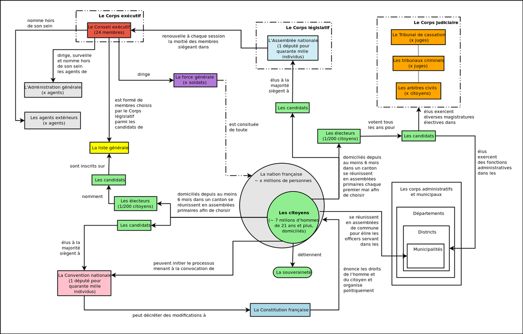

Schéma des institutions de la Constitution du 6 Messidor an I<sup>er</sup>

La Constitution est précédée d’une Déclaration des Droits de l’Homme et du Citoyen révisée. Cette nouvelle version affirme la **souveraineté populaire** plutôt que **nationale**: la souveraineté appartient au peuple concret, la somme des individus, plutôt qu’à un corps abstrait national.  
Des **droits économiques et sociaux** sont affirmés (association, réunion, travail, assistance, instruction), en revanche la protection de la propriété prend moins de place, sans être absente. L’**esclavage** est explicitement interdit; l’**insurrection** contre un pouvoir abusif est proclamée par le dernier article de la Déclaration *le plus sacré des droits et le plus indispensable des devoirs*.

> **DÉCLARATION DES DROITS DE L’HOMME ET DU CITOYEN**

> Le peuple français, convaincu que l’oubli et le mépris des droits naturels de l’homme sont les seules causes des malheurs du monde, a résolu d’exposer dans une déclaration solennelle ces droits sacrés et inaliénables, afin que tous les citoyens, pouvant comparer sans cesse les actes du gouvernement avec le but de toute institution sociale, ne se laissent jamais opprimer, avilir par la tyrannie ; afin que le peuple ait toujours devant les yeux les bases de sa liberté, de son bonheur, le magistrat la règle de ses devoirs, le législateur l’objet de sa mission.

> En conséquence, il proclame, en présence de l’Être suprême la Déclaration suivante des droits de l’homme et du citoyen.

> **Art. I<sup>er</sup>.** Le but de la société est le bonheur commun. Le gouvernement est institué pour garantir à l’homme la jouissance de ses droits naturels et imprescriptibles.

> **II.** Ces droits sont l’égalité, la liberté, la sûreté, la propriété.

> **III.** Tous les hommes sont égaux par nature et devant la loi.

> **IV.** La loi est l’expression libre et solennelle de la volonté générale ; elle est la même pour tous, soit qu’elle protège, soit qu’elle punisse ; elle ne peut ordonner que ce qui est juste et utile à la société ; elle ne peut défendre que ce qui lui est nuisible.

> **V.** Tous les citoyens sont également admissibles aux emplois publics. Les peuples libres ne connaissent d’autres motifs de préférence, dans leurs élections, que les vertus et les talents.

> **VI.** La liberté est le pouvoir qui appartient à l’homme de faire tout ce qui ne nuit pas aux droits d’autrui ; elle a pour principe la nature ; pour règle la justice ; pour sauvegarde la loi ; sa limite morale est dans cette maxime : ne fais pas à un autre ce que tu ne veux pas qu’il te soit fait.

> **VII.** Le droit de manifester sa pensée et ses opinions, soit par la voie de la presse, soit de toute autre manière, le droit de s’assembler paisiblement, le libre exercice des cultes, ne peuvent être interdits. *La nécessité d’énoncer ces droits suppose ou la présence ou le souvenir récent du despotisme.*

> **VIII.** La sûreté consiste dans la protection accordée par la société à chacun de ses membres pour la conservation de sa personne, de ses droits et de ses propriétés.

> **IX.** La loi doit protéger la liberté publique et individuelle contre l’oppression de ceux qui gouvernent.

> **X.** Nul ne doit être accusé, arrêté ni détenu, que dans les cas déterminés par la loi et selon les formes qu’elle a prescrites ; tout citoyen, appelé ou saisi par l’autorité de la loi doit obéir à l’instant ; il se rend coupable par la résistance.

> **XI.** Tout acte exercé contre un homme hors des cas et sous les formes que la loi détermine, est arbitraire et tyrannique ; celui contre lequel on voudrait l’exécuter par la violence a le droit de le repousser par la force.

> **XII.** Ceux qui solliciteraient, expédieraient, signeraient, exécuteraient ou feraient exécuter des actes arbitraires, sont coupables et doivent être punis.

> **XIII.** Tout homme étant présumé innocent jusqu’à ce qu’il ait été déclaré coupable, s’il est jugé indispensable de l’arrêter, toute rigueur qui ne serait pas nécessaire pour s’assurer de sa personne doit être sévèrement réprimée par la loi.

> **XIV.** Nul ne doit être jugé et puni qu’après avoir été entendu ou légalement appelé, et qu’en vertu d’une loi promulguée antérieurement au délit. La loi qui punirait des délits commis avant qu’elle existât serait une tyrannie ; l’effet rétroactif donné à la loi serait un crime.

> **XV.** La loi ne doit décerner que des peines strictement et évidemment nécessaires ; les peines doivent être proportionnées au délit et utiles à la société.

> **XVI.** Le droit de propriété est celui qui appartient à tout citoyen de jouir et de disposer à son gré de ses biens, de ses revenus, du fruit de son travail et de son industrie.

> **XVII.** Nul genre de travail, de culture, de commerce, ne peut être interdit à l’industrie des citoyens.

> **XVIII.** Tout homme peut engager ses services, son temps ; mais il ne peut se vendre ni être vendu ; sa personne n’est pas une propriété aliénable. La loi ne reconnaît point de domesticité ; il ne peut exister qu’un engagement de soins et de reconnaissance, entre l’homme qui travaille et celui qui l’emploie.

> **XIX.** Nul ne peut être privé de la moindre portion de sa propriété sans son consentement si ce n’est lorsque la nécessité publique légalement constatée l’exige, et sous la condition d’une juste et préalable indemnité.

> **XX.** Nulle contribution ne peut être établie que pour l’utilité générale. Tous les citoyens ont le droit de concourir à l’établissement des contributions, d’en surveiller l’emploi, et de s’en faire rendre compte.

> **XXI.** Les secours publics sont une dette sacrée. La société doit la subsistance aux citoyens malheureux, soit en leur procurant du travail, soit en assurant les moyens d’exister à ceux qui sont hors d’état de travailler.

> **XXII.** L’instruction est le besoin de tous. La société doit favoriser de tout son pouvoir les progrès de la raison publique, et mettre l’instruction à la portée de tous les citoyens.

> **XXIII.** La garantie sociale consiste dans l’action de tous pour assurer à chacun la jouissance et la conservation de ses droits ; cette garantie repose sur la souveraineté nationale.

> **XXIV.** Elle ne peut exister, si les limites des fonctions publiques ne sont pas clairement déterminées par la loi, et si la responsabilité de tous les fonctionnaires n’est pas assurée.

> **XXV.** La souveraineté réside dans le peuple ; elle est une et indivisible, imprescriptible et inaliénable.

> **XXVI.** Aucune portion du peuple ne peut exercer la puissance du peuple entier ; mais chaque section du souverain assemblée doit jouir du droit d’exprimer sa volonté avec une entière liberté.

> **XXVII.** Que tout individu qui usurperait la souveraineté soit à l’instant mis à mort par les hommes libres.

> **XXVIII.** Un peuple a toujours le droit de revoir, de réformer et de changer sa Constitution. Une génération ne peut assujettir à ses lois les générations futures.

> **XXIX.** Chaque citoyen a un droit égal de concourir à la formation de la loi et à la nomination de ses mandataires ou de ses agents.

> **XXX.** Les fonctions publiques sont essentiellement temporaires ; elles ne peuvent être considérées comme des distinctions ni comme des récompenses, mais comme des devoirs.

> **XXXI.** Les délits des mandataires du peuple et de ses agents ne doivent jamais être impunis. Nul n’a le droit de se prétendre plus inviolable que les autres citoyens.

> **XXXII.** Le droit de présenter des pétitions aux dépositaires de l’autorité publique ne peut, en aucun cas, être interdit, suspendu ni limité.

> **XXXIII.** La résistance à l’oppression est la conséquence des autres droits de l’homme.

> **XXXIV.** Il y a oppression contre le corps social, lorsqu’un seul de ses membres est opprimé. Il y a oppression contre chaque membre lorsque le corps social est opprimé.

> **XXXV.** Quand le gouvernement viole les droits du peuple, l’insurrection est, pour le peuple et pour chaque portion du peuple, le plus sacré des droits et le plus indispensable des devoirs.

> Signé : COLLOT-D’HERBOIS, Président ; Durand Maillane, Ducos, Meaulle, Ch. Delacroix, Gossuin, P. A. Laloy, Secrétaires.

Mais la Constitution n’est jamais appliquée: elle est suspendue jusqu’à la paix. si le fonctionnement réel de la France sous la Convention n’est pas celui que l’on vise, la pratique repose sur la même aspiration démocratique.  
Le 19 Vendémiaire An II, la Constitution est suspendue: la France est déclarée révolutionnaire jusqu’à la paix. Cela répond à la situation d’urgence: un ordre constitutionnel ne peut régner que lorsque la sécurité est assurée. Le régime d’urgence et d’exception est explicitement placé en dehors de l’ordre constitutionnel. Le décret de 5 Nivôse An II explicite cette différence: le gouvernement constitutionnel a pour but de conserver la République, le gouvernement révolutionnaire a pour but de la fonder. Il est par définition provisoire.Mais le Comité de salut public **refuse de s’ériger en gouvernement provisoire**, puisque l’exécutif ne doit être qu’un moyen et rester subordonné au législatif.

Le modèle politique de la république de la période de la Convention repose, dans la réalité concrète de la vie politique, sur l’activité intense des sections. Elles sont le lieu de discussion, de sociabilité et de prise de décision qui organise l’activité politique des citoyens. Si le degré d’autonomie des sections pouvait faire objet de conflit (la demande d’organisation des fêtes sectionnaires a été refusée au nom de l’unité nationale), les sections sont le principal maillage de la république à l’**échelle de la connaissance**.

## 3 La république sans vertu: Thermidor

### 3.1 9 Thermidor

Les événements du 9 Thermidor (27 juillet 1794) sont un coup d’État anti-révolutionnaire. Contrairement à certaines représentations produites récemment, les documents d’époque ne témoignent d’aucune joie ni de soulagement à la fin de la Terreur: les récits que nous avons de Thermidor sont plutôt lugubres et montrent que la chute des Robespierristes est vécue comme une défaite populaire.  
Le coup d’État au sein de la Convention est en préparation depuis des mois et résulte des conflits accumulés depuis la condamnation de Danton. Un soulèvement populaire est tenté pour défendre la révolution, mais échoue. Pas de soulagement donc, mais une fatigue bien réelle affaiblit la réaction.

La seconde raison pour laquelle l’image d’un soulagement populaire est fausse, c’est que la terreur ne s’arrête pas, elle ne fait que changer de direction. Après l’exécution des Robespierristes, les pratiques de la Terreur continuent, la Terreur se muant éventuellement en terreur blanche. Très rapidement, après la mort des 22 premiers condamnés, guillotinés le 10 Thermidor, la Commune de Paris est liquidée avec 71 exécutions le lendemain, puis encore 12 le jour suivant. La loi de Prairial est abrogée sans débat après quoi le tribunal révolutionnaire est paralysé et de fait suspendu pendant plusieurs jours.

### 3.2 Un régime de guerre civile

Thermidor démonte les lois de l’An II, mais, plus important encore, s’applique à détruire l’espace public démocratique qui avait marqué les années révolutionnaires.  
La Commune de Paris est pratiquement détruite, les sections perdent les moyens de leur influence. Le club des Jacobins fait objet d’une épuration pour devenir un relais du pouvoir mais non plus un lieu de discussion, et encore moins de contrôle des institutions.Les sans-culottes sont désarmés. Après la suppression du Tribunal révolutionnaire, ce sont les commissions militaires qui sont chargées des procès politiques, dans un contexte tendu: les mesures économiques de Thermidor, notamment la fin de la loi du Maximum (qui encadrait les prix) replonge le petit peuple dans la misère tandis que l’**assignat** (monnaie révolutionnaire, une de premières monnaies-papier modernes en Occident) perd rapidement de la valeur. Face aux demandes d’appliquer enfin la constitution de 1793, il est d’abord décidé de l’encadrer de lois organiques puis, après des insurrections populaires écrasées, de la remplacer par une nouvelle constitutions (de l’An III), dont le rapporteur est **Bussy d’Anglas**. La nouvelle constitution est résolument réactionnaire, en retrait même des principes posés en 1789.

> Nous devons être gouvernés par les meilleurs. Les meilleurs sont les plus instruits et les plus intéressés au maintien des lois. Or, à bien peu d’exceptions près, vous ne trouverez de pareils hommes que parmi ceux qui possèdent une propriété,sont attachés au pays qui la contient, aux lois qui la protègent, à la tranquillité qui la conserve, et qui doivent à cette propriété et à l’aisance qu’elle donne, l’éducation qui les a rendu propres à discuter avec sagacité et justesse les avantages et les inconvénients des lois qui fixent le sort de leur patrie […] Un pays gouverné par les propriétaires est dans l’ordre social, celui où les non-propriétaires gouvernent est dans l’état de nature.

> Bussy d’Anglas, le 5 Messidor An III (23 juin 1795)

Le même Bussy d’Anglas est hostile à un *peuple constamment délibérant*: pour lui, l’anarchie et la tyrannie ont en commun la suspicion à l’égard des riches qu’il s’agirait d’éradiquer. La Déclaration des droits de l’Homme et du Citoyen ne disparaît pas (même si certains Thermidoriens le souhaiteraient, ce qu’ils justifient en soutenant qu’elle serait sans objet désormais), mais elle est affaiblie et assortie d’une déclaration des devoirs (proposée sans succès en 1789), qui demande en fait une soumission pure est simple.  
L’exécutif, qui a le pouvoir de nommer les généraux et les ambassadeurs, prend le pas sur le législatif, d’autant plus que malgré l’affirmation de retour à un ordre constitutionnel strict, les mesures d’exception restent en vigueur. L’armée est un instrument de pouvoir et un recours constant, autant pour la justice d’exception que pour des interventions directes dans l’ordre politique: ainsi, la poussé royaliste aux élections de 5 Fructidor An III (22 août 1795) suivi d’une véritable insurrection des beaux quartiers le 13 Vendémiaire (5 octobre 1795), est réprimée par l’armée commandée par Napoléon Bonaparte.

Les tenants d’une révolution radicale sont poursuivis. **Gracchus Babœuf**, leader de la Conjuration **des Égaux**, est attiré dans une provocation policière et condamné, ses partisans font objet de répression.

> La Révolution française n’est que l’avant-courrière d’une révolution bien plus grande, qui sera la dernière. Ce qu’il faut de plus que l’égalité des droits? Il ne nous faut pas seulement cette égalité transcrite dans la Déclaration des droits de l’homme et du citoyen, nous la voulons au milieu de nous, sous le toit de nos maisons. Nous voulons le bien commun ou la communauté des bien! Plus de propriété individuelle, la terre n’est à personne, les fruits sont à tout le monde. Disparaissez enfin, révoltantes distinctions de riches et de pauvres, de maîtres et de valets, de gouvenants et de gouvernés. L’instant est venu de fonder la République des Égaux.

> *Manifeste des Égaux*, 1795

### 3.3 La naissance de l’extrême-centre

La pratique politique de Thermidor, qui entend clore la révolution et qui maintient la république, devenue autoritaire, aussi méfiante de la monarchie que de son passé jacobin, n’est pas sans postérité.  
**Pierre Serna**, spécialiste de cette période, a forgé le terme d’**extrême-centre** pour qualifier la politique thermidorienne. Il s’agit d’un mélange de modération dans les propos et dans le langage, permettant d’afficher le rejet de la violence, de véritable violence dans la pratique, et de malléabilité idéologique. La république de Thermidor se méfie du peuple qu’elle entend contrôler avec l’aide de l’armée, au nom de la nécessité perçue (la **raison d’État**) et de l’intérêt des propriétaires aisés.